# Generalized Additive Model

# 1 Generalized Additive Model

There are two common implementations of GAMs in R. The older version (originally made for S-PLUS) is available as the ‘gam’ package by Hastie and Tibshirani. The newer version that we will use below is the ‘mgcv’ package from Simon Wood. The basic modeling procedure for both packages is similar (the function is gam for both; be wary of having both libraries loaded at the same time), but the behind-the-scenes computational approaches differ, as do the arguments for optimization and the model output. Expect the results to be slightly different when used with the same model structure on the same dataset.

## 1.1 GAM on Boston Housing dataset

```r
library(MASS)
set.seed(1234)
sample_index <- sample(nrow(Boston),nrow(Boston)*0.70)
Boston_train <- Boston[sample_index,]
Boston_test <- Boston[-sample_index,]
str(Boston_train)
```

**Model and plots**

```r
library(mgcv)

#create gam model
Boston_gam <- gam(medv ~ s(crim)+s(zn)+s(indus)+chas+s(nox)
                 +s(rm)+s(age)+s(dis)+rad+s(tax)+s(ptratio)
                 +s(black)+s(lstat),data=Boston_train)

summary(Boston_gam)
```

```
##
## Family: gaussian
## Link function: identity
##
## Formula:
## medv ~ s(crim) + s(zn) + s(indus) + chas + s(nox) + s(rm) + s(age) +
##     s(dis) + rad + s(tax) + s(ptratio) + s(black) + s(lstat)
##
## Parametric coefficients:
##             Estimate Std. Error t value Pr(>|t|)
## (Intercept)  18.9672     1.4638  12.958   <2e-16 ***
## chas          1.0098     0.7104   1.421   0.1562
## rad           0.3454     0.1505   2.296   0.0224 *
## ---
## Signif. codes:  0 '***' 0.001 '**' 0.01 '*' 0.05 '.' 0.1 ' ' 1
##
## Approximate significance of smooth terms:
##              edf Ref.df      F  p-value
## s(crim)    4.543  5.488  7.436 1.29e-06 ***
## s(zn)      1.000  1.000  0.973  0.32465
## s(indus)   6.701  7.629  4.124  0.00018 ***
## s(nox)     8.946  8.995 17.931  < 2e-16 ***
## s(rm)      7.792  8.605 19.944  < 2e-16 ***
## s(age)     2.415  3.058  1.302  0.28297
## s(dis)     8.742  8.975  8.895  < 2e-16 ***
## s(tax)     6.122  7.145  7.091  < 2e-16 ***
## s(ptratio) 1.000  1.000 21.257 6.20e-06 ***
## s(black)   1.000  1.000  0.002  0.96366
## s(lstat)   6.362  7.484 18.551  < 2e-16 ***
## ---
## Signif. codes:  0 '***' 0.001 '**' 0.01 '*' 0.05 '.' 0.1 ' ' 1
##
## R-sq.(adj) =  0.893   Deviance explained =   91%
## GCV = 10.713  Scale est. = 8.9693    n = 354
```

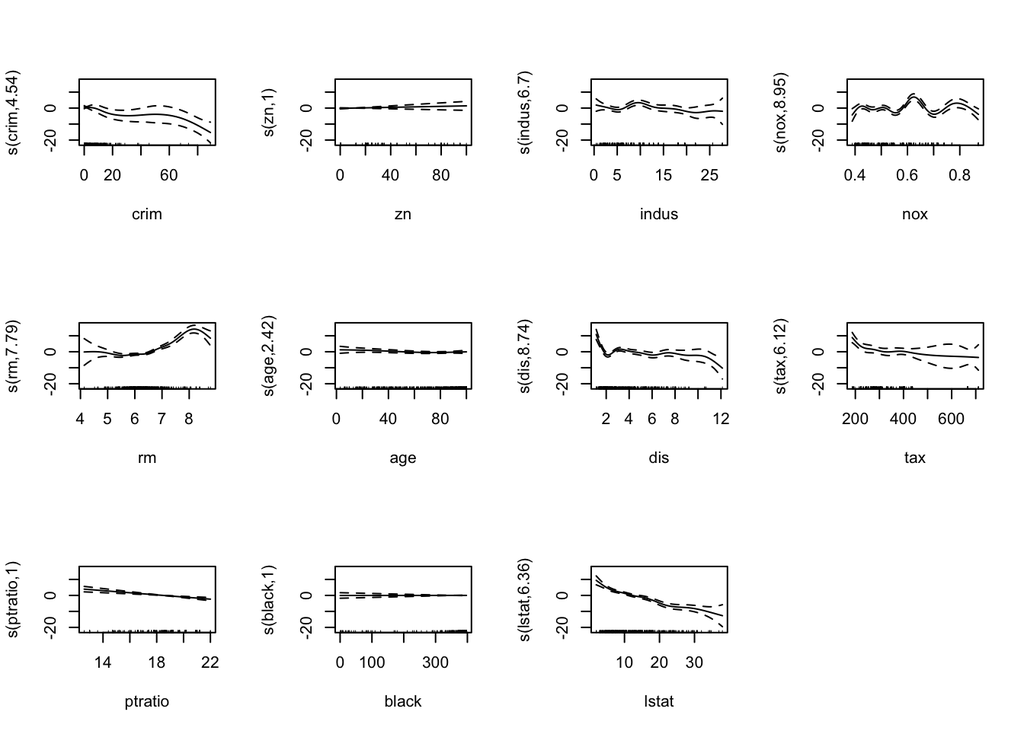

```r
plot(Boston_gam, pages=1)
```

**Model AIC/BIC and mean residual deviance**

```r
AIC(Boston_gam)
BIC(Boston_gam)
Boston_gam$deviance
```

**In-sample fit performance**

```r
#in-sample mse using df
Boston_gam.mse.train <- Boston_gam$dev/Boston_gam$df.residual
#Average Sum of Squared Error
Boston_gam.mse.train <- Boston_gam$dev/nrow(Boston_train)

#using the predict() function
pi <- predict(Boston_gam,Boston_train)
mean((pi - Boston_train$medv)^2)
```

```
## [1] 7.509325
```

**out of sample performance**

```r
pi.out <- predict(Boston_gam,Boston_test)
mean((pi.out - Boston_test$medv)^2)
```

```
## [1] 14.04571
```

go to top

## 1.2 GAM on Credit Card Default Data

```r
credit_data <- read.csv(file = "https://yanyudm.github.io/Data-Mining-R/lecture/data/credit_default.csv", header=T)

# rename
library(dplyr)
credit_data<- rename(credit_data, default=default.payment.next.month)
# convert categorical data to factor
credit_data$SEX <- as.factor(credit_data$SEX)
credit_data$EDUCATION <- as.factor(credit_data$EDUCATION)
credit_data$MARRIAGE <- as.factor(credit_data$MARRIAGE)
```

Now split the data 90/10 as training/testing datasets:

```r
index <- sample(nrow(credit_data),nrow(credit_data)*0.90)
credit_train = credit_data[index,]
credit_test = credit_data[-index,]
```

Some of these predictors are categorical variables and they will enter the `gam()` model as partially linear terms. We only add flexible `s()` function to those continuous predictor variables such as LIMIT_BAL, AGE etc. Here we will demonstrate using five continuous variables as smooth terms and three categorical variables SEX, EDUCATION, and MARRIAGE as partially linear terms to save the space of summary output.

```r
## Create a formula for a model with a large number of variables:
gam_formula <- as.formula("default~s(LIMIT_BAL)+s(AGE)+s(PAY_0)+s(BILL_AMT1)+s(PAY_AMT1)+SEX+EDUCATION+MARRIAGE")

credit_gam <- gam(formula = gam_formula, family=binomial, data=credit_train);
summary(credit_gam)
```

```
##
## Family: binomial
## Link function: logit
##
## Formula:
## default ~ s(LIMIT_BAL) + s(AGE) + s(PAY_0) + s(BILL_AMT1) + s(PAY_AMT1) +
##     SEX + EDUCATION + MARRIAGE
##
## Parametric coefficients:
##              Estimate Std. Error z value Pr(>|z|)
## (Intercept) -1.238725   0.067409 -18.376  < 2e-16 ***
## SEX2        -0.164904   0.053905  -3.059  0.00222 **
## EDUCATION2  -0.055720   0.061951  -0.899  0.36843
## EDUCATION3  -0.203156   0.084394  -2.407  0.01607 *
## EDUCATION4  -1.424943   0.338854  -4.205 2.61e-05 ***
## MARRIAGE2   -0.138104   0.060675  -2.276  0.02284 *
## MARRIAGE3    0.002647   0.233595   0.011  0.99096
## ---
## Signif. codes:  0 '***' 0.001 '**' 0.01 '*' 0.05 '.' 0.1 ' ' 1
##
## Approximate significance of smooth terms:
##                edf Ref.df   Chi.sq p-value
## s(LIMIT_BAL) 5.727  6.621  145.428 < 2e-16 ***
## s(AGE)       1.022  1.044    2.329 0.12953
## s(PAY_0)     6.848  7.575 1247.069 < 2e-16 ***
## s(BILL_AMT1) 3.706  4.631   48.692 < 2e-16 ***
## s(PAY_AMT1)  4.981  6.140   26.129 0.00024 ***
## ---
## Signif. codes:  0 '***' 0.001 '**' 0.01 '*' 0.05 '.' 0.1 ' ' 1
##
## R-sq.(adj) =  0.206   Deviance explained = 17.6%
## UBRE = -0.1273  Scale est. = 1         n = 10800
```

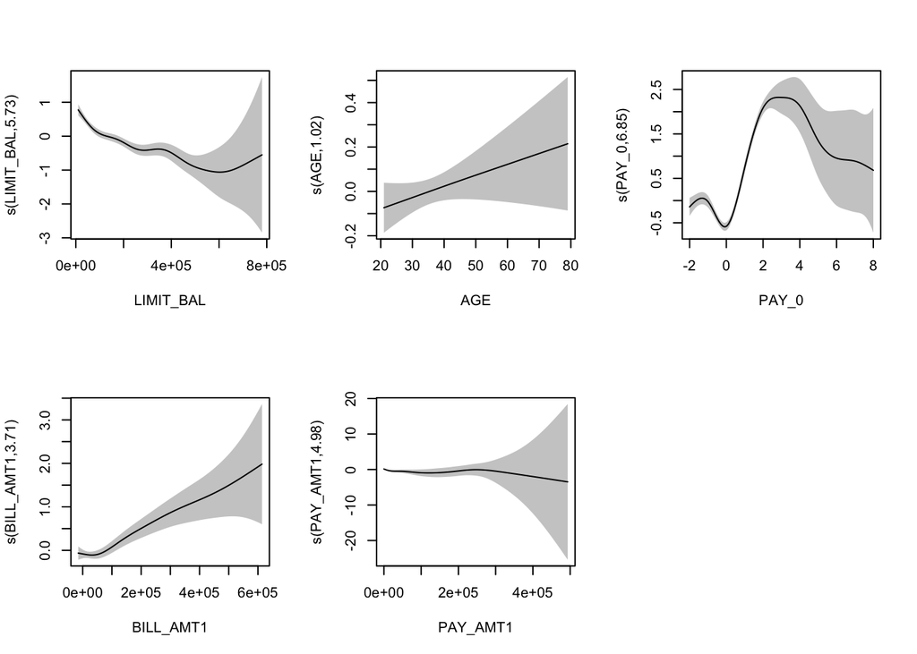

```r
plot(credit_gam, shade=TRUE, seWithMean=TRUE, scale=0, pages = 1)
```

The function `vis.gam()` can visualize the nonlinear relationship between two variables and the linear predictor in a 3D space as follows:

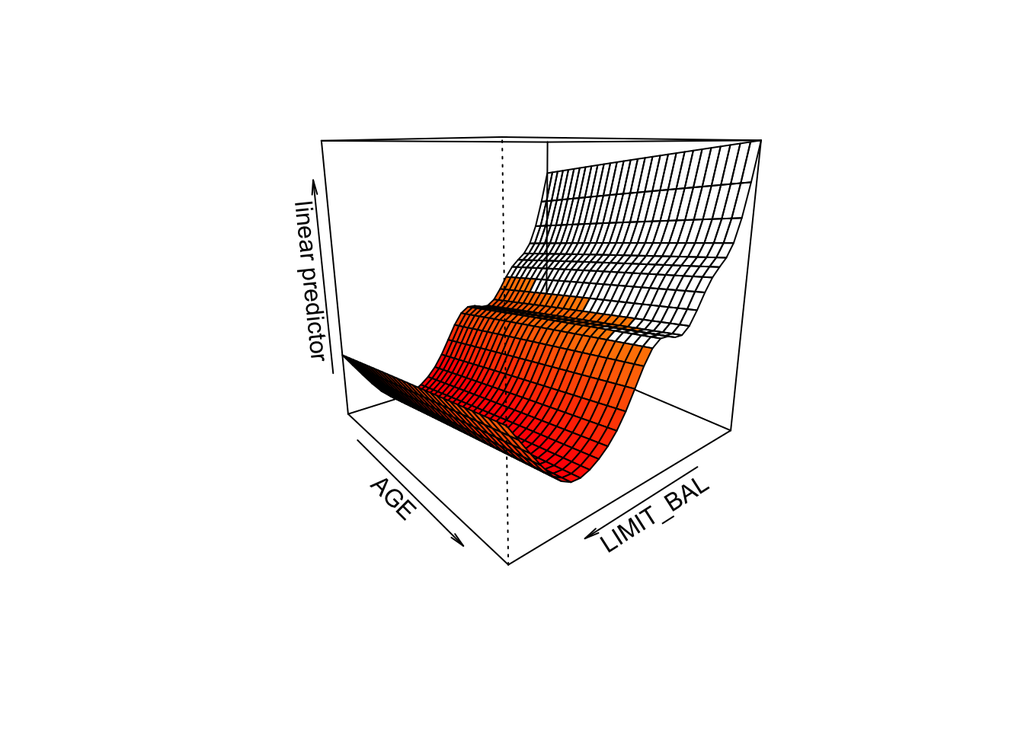

```r
# vis.gam(credit_gam)
vis.gam(credit_gam, view=c("LIMIT_BAL","AGE"), theta= 140) # different view
```

### 1.2.1 In-sample fit performance

In order to see the in-sample fit performance, you may look into the confusion matrix by using commands as following. We assume the cut-off probability as 1/6.

```r
pcut_gam <- 1/6
prob_gam_in <-predict(credit_gam,credit_train,type="response")
pred_gam_in <- (prob_gam_in>=pcut_gam)*1
table(credit_train$default, pred_gam_in,dnn=c("Observed","Predicted"))
```

```
##         Predicted
## Observed    0    1
##        0 5849 2581
##        1  719 1651
```

The asymmetric cost with 5:1 cost ratio is:

```r
creditcost <- function(r, pi){
  weight1 = 5
  weight0 = 1
  pcut <- weight0/(weight0+weight1)
  c1 = (r==1)&(pi<pcut) #logical vector - true if actual 1 but predict 0
  c0 = (r==0)&(pi>pcut) #logical vector - true if actual 0 but predict 1
  return(mean(weight1*c1+weight0*c0))
}
creditcost(credit_train$default, prob_gam_in)
```

```
## [1] 0.5718519
```

Training model AIC, BIC, and mean residual deviance:

```r
AIC(credit_gam)
```

```
## [1] 9425.127
```

```r
BIC(credit_gam)
```

```
## [1] 9638.527
```

```r
# credit_gam$deviance
```

**ROC Curve:**

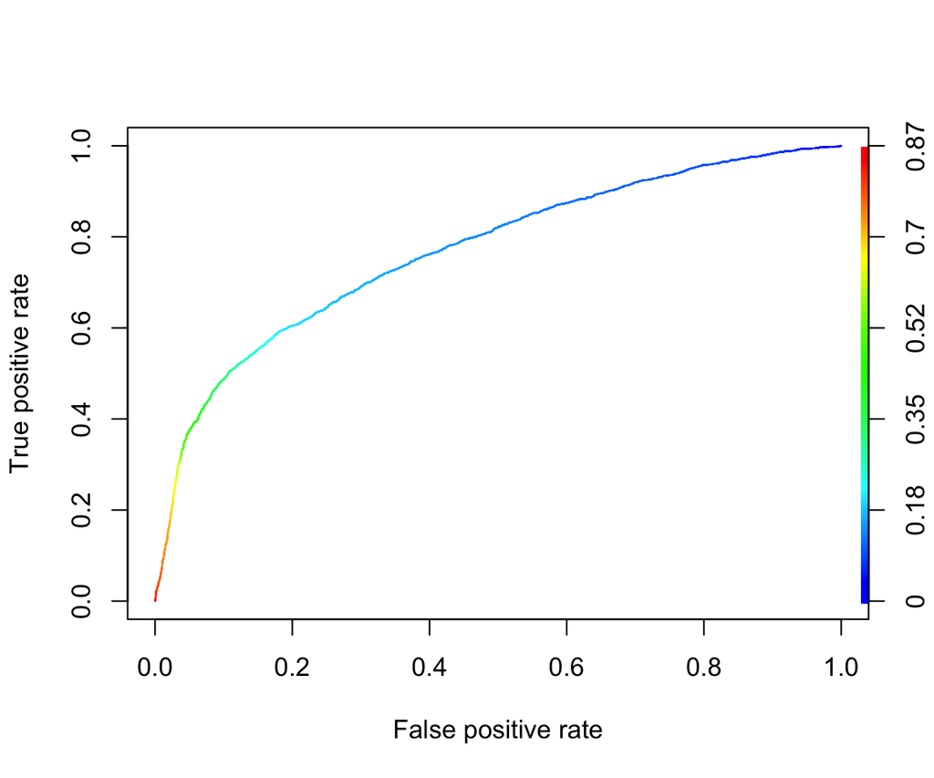

```r
library(ROCR)
pred <- prediction(predictions = c(prob_gam_in), labels = credit_train$default)
perf <- performance(pred, "tpr", "fpr")
plot(perf, colorize=TRUE)
```

```r
#Get the AUC
unlist(slot(performance(pred, "auc"), "y.values"))
```

```
## [1] 0.7681283
```

### 1.2.2 Out-of-sample fit performance

```r
pcut <- 1/6
prob_gam_out <- predict(credit_gam, credit_test,type="response")
pred_gam_out <- (prob_gam_out>=pcut)*1
table(credit_test$default, pred_gam_out,dnn=c("Observed","Predicted"))
```

```
##         Predicted
## Observed   0   1
##        0 625 313
##        1  88 174
```

The asymmetric cost is

```r
creditcost(credit_test$default, prob_gam_out)
```

```
## [1] 0.6275
```

**ROC Curve:**

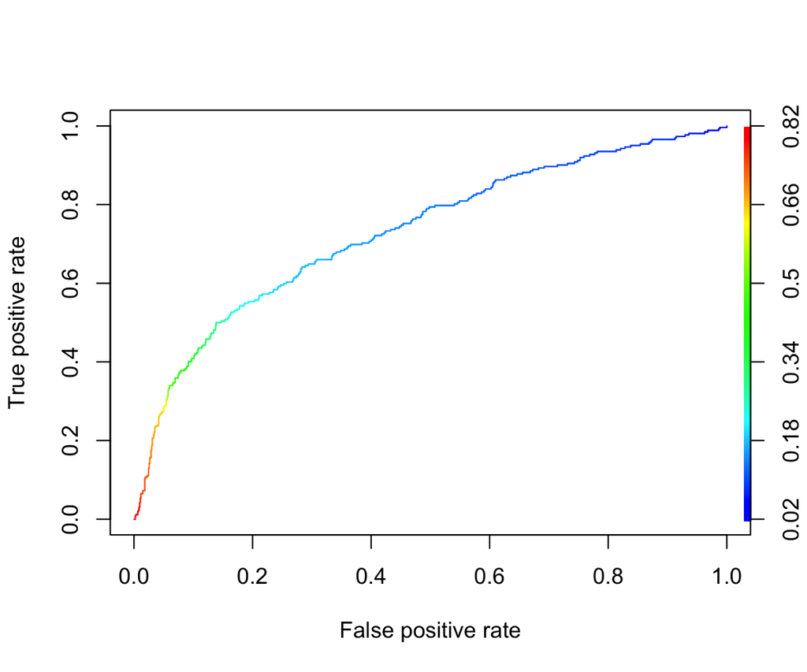

```r
pred <- prediction(predictions = c(prob_gam_out), labels = credit_test$default)
perf <- performance(pred, "tpr", "fpr")
plot(perf, colorize=TRUE)
```

```r
#Get the AUC
unlist(slot(performance(pred, "auc"), "y.values"))
```

```
## [1] 0.7306678
```

go to top

## 1.3 GAM using the “Motorcycle” dataset

Finally, we can also apply `gam()` for a univariate smoothing on the motorcycle data.

```r
library(MASS)
data('mcycle')
str(mcycle)
summary(mcycle)
```

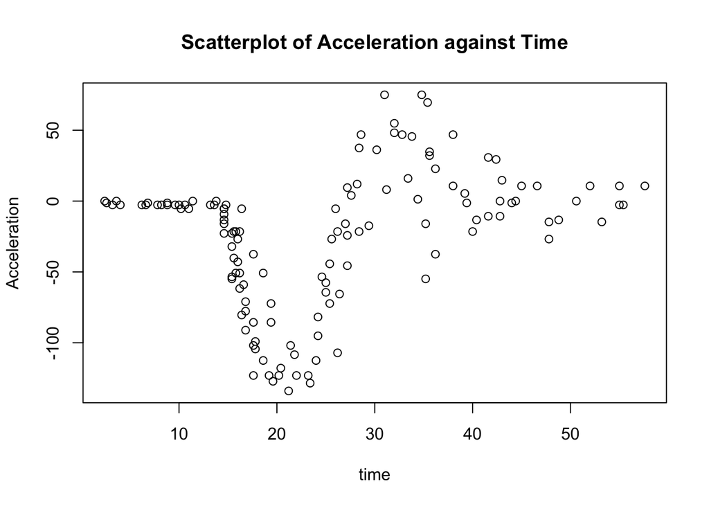

```r
# Rename the variables for ease of usage
Y <- mcycle$accel
X <- mcycle$times

#Scatterplot
plot(Y~X, xlab="time",ylab="Acceleration", main="Scatterplot of Acceleration against Time")
```

```r
library(mgcv)
s_gam <- gam(Y ~ s(X),data=mcycle)
summary(s_gam)
```

```
##
## Family: gaussian
## Link function: identity
##
## Formula:
## Y ~ s(X)
##
## Parametric coefficients:
##             Estimate Std. Error t value Pr(>|t|)
## (Intercept)  -25.546      1.951   -13.1   <2e-16 ***
## ---
## Signif. codes:  0 '***' 0.001 '**' 0.01 '*' 0.05 '.' 0.1 ' ' 1
##
## Approximate significance of smooth terms:
##        edf Ref.df     F p-value
## s(X) 8.693  8.972 53.52  <2e-16 ***
## ---
## Signif. codes:  0 '***' 0.001 '**' 0.01 '*' 0.05 '.' 0.1 ' ' 1
##
## R-sq.(adj) =  0.783   Deviance explained = 79.8%
## GCV = 545.78  Scale est. = 506       n = 133
```

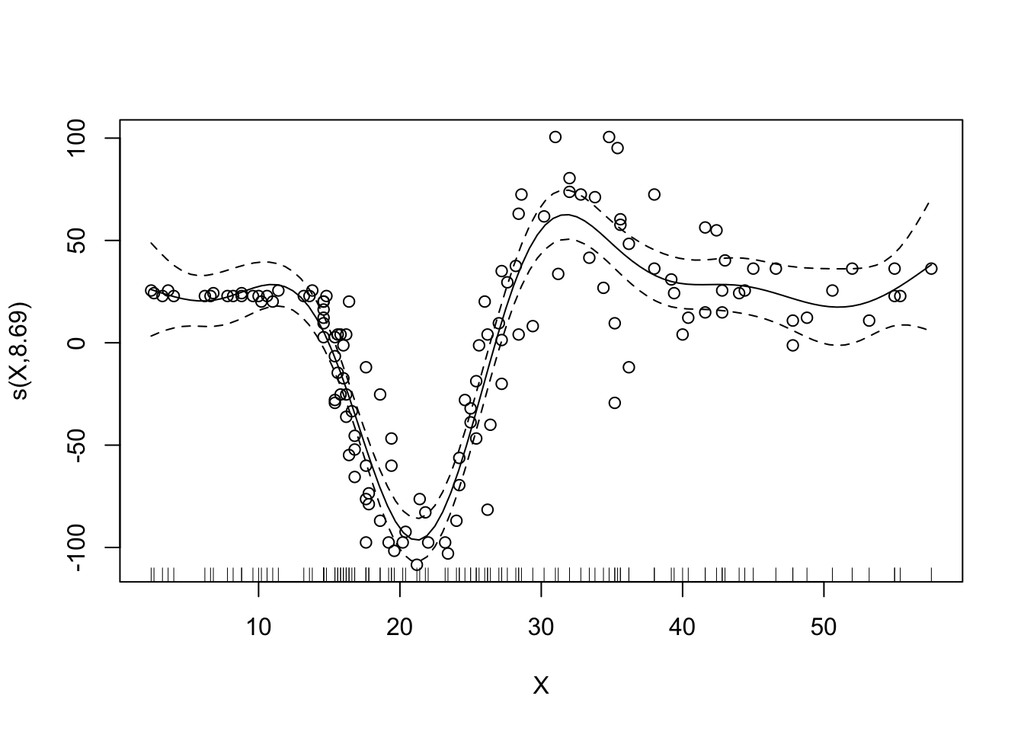

```r
#plot the model
plot(s_gam, residuals = TRUE, pch = 1)
```

go to top